# Module 4: Estimating the ACVF and ACF

STAT 4170 – Financial Time Series and Forecasting

Taylor R. Brown

# Part 0: The General Setting

## Two Kinds of Processes

Everything in this module — and most of the course — lives in one of two worlds.

**Stationary process:** $\{X_t\}$ is (weakly) stationary if

- $E[X_t] = \mu$ is constant (does not depend on $t$)
- $\text{Cov}(X_{t+h}, X_t) = \gamma_X(h)$ depends only on the lag $h$, not on $t$

The process “looks the same” wherever you look at it. Its mean and covariance structure are stable over time.

**Non-stationary process:** at least one of those conditions fails — the mean drifts, the variance grows, or correlations depend on when in time you are.

## Why the Distinction Matters for Estimation

When a process is stationary, a single long realization gives us information about the whole process — different time points are all draws from the same distributional structure, just shifted in time. **Time averaging substitutes for ensemble averaging.**

When a process is non-stationary, the structure at time $t=100$ may have nothing to do with the structure at $t=1$. A sample mean or sample correlation computed from such a path can be misleading or meaningless.

The two canonical examples we will use throughout this module:

| Process | Stationary? | ACVF |
| --- | --- | --- |
| IID noise $X_t \overset{\text{iid}}{\sim} (0, \sigma^2)$ | Yes | $\gamma(0) = \sigma^2$, $\gamma(h) = 0$ for $h \neq 0$ |
| Random walk $S_t = \sum_{i=1}^t Z_i$ | No | $\gamma(t+h, t) = t\sigma^2$ — depends on $t$ |

# Part 1: Distribution of the Sample Mean

## The IID Setting

Let $X_1, \ldots, X_n \overset{\text{iid}}{\sim} (\mu, \sigma^2)$. The sample mean is

$$\bar{X} = \frac{1}{n} \sum_{t=1}^n X_t$$

By linearity of expectation: $E[\bar{X}] = \mu$.

By independence, the cross-covariances vanish:

$$\text{Var}(\bar{X}) = \frac{1}{n^2} \sum_{t=1}^n \text{Var}(X_t) = \frac{n \sigma^2}{n^2} = \frac{\sigma^2}{n}$$

The IID structure means off-diagonal terms $\text{Cov}(X_i, X_j) = 0$ — each observation is new information. **More data always helps.**

## Independence Simplifies Everything to $\sigma^2/n$

The general expression for any zero-mean stationary process is

$$\text{Var}(\bar{X}) = \frac{1}{n^2} \sum_i \sum_j \text{Cov}(X_i, X_j) = \frac{1}{n} \sum_{h=-(n-1)}^{n-1} \left(1 - \frac{|h|}{n}\right) \gamma_X(h)$$

For IID noise, $\gamma_X(h) = 0$ for all $h \neq 0$, so only the $h=0$ term survives:

$$\text{Var}(\bar{X}) = \frac{1}{n} \cdot \gamma_X(0) = \frac{\sigma^2}{n}$$

When observations have some correlation at nonzero lags, variance can shrink much more slowly as you add more data. The “effective sample size” is smaller than actual sample size $n$.

## Counting the $\gamma(h)$ Terms in the Double Sum

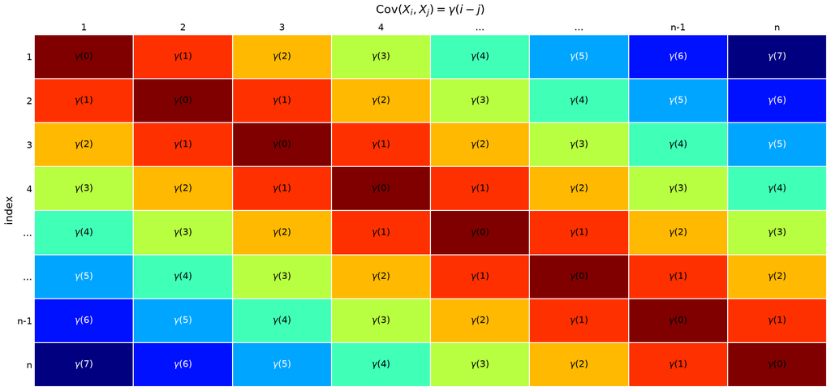

## By CLT, the Sample Mean is Asymptotically Normal

For IID noise with finite variance, the CLT gives:

$$\sqrt{n}\,\bar{X} \xrightarrow{d} N(0, \sigma^2) \quad \Longleftrightarrow \quad \bar{X} \overset{\text{approx}}{\sim} N\!\left(0, \frac{\sigma^2}{n}\right)$$

**Key property:** the standard deviation of $\bar{X}$ shrinks at rate $1/\sqrt{n}$.

Double the sample size → $\bar{X}$’s variance halves.

## Don’t Take the Time Average of a Random Walk

Rewrite $S_t = S_{t-1} + Z_t$ as $S_t = Z_1 + \cdots + Z_t$ with $\{Z_t\} \overset{\text{iid}}{\sim} (0, \sigma^2)$. The sample mean of a length-$n$ random walk path is:

$$\bar{S} = \frac{1}{n} \sum_{t=1}^n S_t = \frac{1}{n} \sum_{t=1}^n \sum_{i=1}^t Z_i = \frac{1}{n} \sum_{i=1}^n (n - i + 1) Z_i$$

The good news is it’s unbiased:

$$E[\bar{S}] = 0$$

but…

## Don’t Take the Time Average of a Random Walk

$$\bar{S} = \frac{1}{n} \sum_{t=1}^n S_t = \frac{1}{n} \sum_{t=1}^n \sum_{i=1}^t Z_i = \frac{1}{n} \sum_{i=1}^n (n - i + 1) Z_i$$

The accuracy of this estimator gets **worse with more data!**

$$\text{Var}(\bar{S}) = \frac{\sigma^2}{n^2} \sum_{i=1}^n (n - i + 1)^2 = \frac{\sigma^2}{n^2} \cdot \frac{n(n+1)(2n+1)}{6} \approx \frac{\sigma^2 n}{3}$$

Calculate the time average $\bar{S}$ to estimate a population mean is essentially meaningless for a random walk, and yet people do it all the time.

## Empirical: Distribution of $\bar{X}$ vs $\bar{S}$

- **IID noise:** does $\bar{X}$ concentrate around zero?
- **Random walk:** does $\bar{S}$ converge to anything?

```python
import numpy as np
import matplotlib.pyplot as plt

rng = np.random.default_rng(42)
B = 3000
ns = [50, 150, 500, 2000]
colors = ["#a8d8ea", "#4a90d9", "#1a4f8a", "#0a1f3a"]

fig, axes = plt.subplots(1, 2, figsize=(11, 4))

for n, color in zip(ns, colors):
    iid_means = np.array([rng.normal(0, 1.0, n).mean() for _ in range(B)])
    rw_means  = np.array([rng.normal(0, 1.0, n).cumsum().mean() for _ in range(B)])
    label = f"n = {n}"
    axes[0].hist(iid_means, bins=60, color=color, alpha=0.5, label=label, density=True)
    axes[1].hist(rw_means,  bins=60, color=color, alpha=0.5, label=label, density=True)

for ax, title in zip(axes, [r"$\bar{X}$ — IID Noise", r"$\bar{S}$ — Random Walk"]):
    ax.axvline(0, color="black", lw=1, ls="--")
    ax.set_title(title, fontsize=13)
    ax.set_xlabel("sample mean", fontsize=11)
    ax.set_ylabel("density", fontsize=11)
    ax.legend(fontsize=9)

plt.suptitle(f"Distribution of sample mean for increasing n  (B = {B} paths each)")
plt.tight_layout()
plt.show()
```

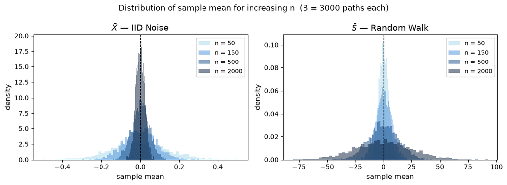

# Part 2: SACF for IID Noise

## Theoretical ACF of IID Noise

Recall: for $\{X_t\} \overset{\text{iid}}{\sim} (0, \sigma^2)$,

$$\rho_X(h) = \begin{cases} 1 & h = 0 \\ 0 & h \neq 0 \end{cases}$$

The **population** ACF is a spike at zero and nothing elsewhere.

What does a **single realization’s** SACF look like? And if we had many independent realizations, how close does the average SACF come to the population?

## Single Realization: IID Noise

```python
import numpy as np
import matplotlib.pyplot as plt
from statsmodels.graphics.tsaplots import plot_acf

rng = np.random.default_rng(42)
n = 300

X = rng.normal(0, 1.0, n)

fig, axes = plt.subplots(1, 2, figsize=(11, 4))
axes[0].plot(X, lw=0.7)
axes[0].set_title("One realization — IID Noise")
axes[0].set_xlabel("time")
axes[0].set_ylabel("$X_t$")
plot_acf(X, lags=20, ax=axes[1], title="SACF of that one realization")
axes[1].set_xlabel("lag $h$")
axes[1].set_ylabel(r"$\hat{\rho}_X(h)$")
plt.tight_layout()
plt.show()
```

## Single Realization: IID Noise

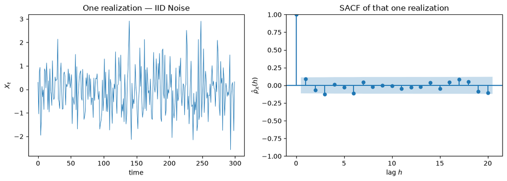

## Sample ACF vs. Population: Many Realizations

```python
import numpy as np
import matplotlib.pyplot as plt
from statsmodels.tsa.stattools import acf

rng = np.random.default_rng(0)
n, B, max_lag = 300, 200, 20

sacf_matrix = np.array([
    acf(rng.normal(0, 1.0, n), nlags=max_lag, fft=True)
    for _ in range(B)
])

lags = np.arange(max_lag + 1)
fig, ax = plt.subplots(figsize=(10, 4))
for row in sacf_matrix:
    ax.plot(lags[1:], row[1:], color="steelblue", alpha=0.07, lw=0.8)
ax.plot(lags[1:], sacf_matrix[:, 1:].mean(axis=0), color="black",
        lw=1.5, label="average SACF across realizations")
ax.axhline(0, color="black", lw=0.8, ls="--")
ax.axhline(1.96 / np.sqrt(n), color="firebrick", ls=":", lw=1)
ax.axhline(-1.96 / np.sqrt(n), color="firebrick", ls=":", lw=1, label="±1.96/√n")
ax.set_xticks(lags[1:])
ax.set_xlim(1, max_lag)
ax.set_xlabel("lag")
ax.set_title(f"SACF across {B} IID realizations (n={n})")
ax.legend()
plt.tight_layout()
plt.show()
```

## Sample ACF vs. Population: Many Realizations

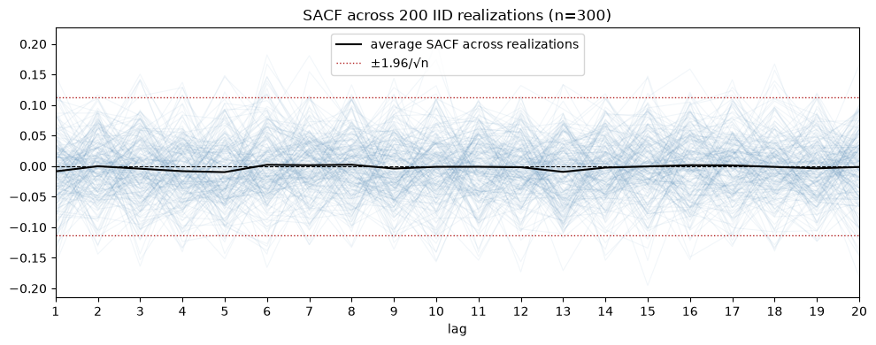

## What We See

Each translucent line is the SACF from one length-300 IID path.

The **average SACF** (black) converges to the population value of 0 at all lags $h \geq 1$ — confirming the estimator is approximately unbiased.

The **spread** of individual SACFs around zero is $\approx 1/\sqrt{n}$ (more on this in part 4)

**Key lesson:** any single realization will show spurious spikes by chance. Seeing two or three lags exceed the bands in a 20-lag plot is expected, not evidence of structure.

# Part 3: SACF for the Random Walk

## Theoretical (Auto?) Correlations of the Random Walk

The random walk is **not stationary**, so there is no single population ACF that doesn’t depend on $t$. There is no **auto**correlation function.

The correlation between $S_{t+h}$ and $S_t$ (for $h \geq 0$) is:

$$\text{Cor}(S_{t+h}, S_t) = \frac{t\sigma^2}{\sqrt{t\sigma^2 \cdot (t+h)\sigma^2}} = \sqrt{\frac{t}{t+h}}$$

This depends on both $t$ and $h$ — there is no single $\rho(h)$.

When $h \ll t$ (looking back a short lag relative to the series length), $\text{Cor}(S_{t+h}, S_t) \approx 1$.

## Slow Decay?

**It is a huge mistake to calculate autocorrelation on a nonstationary process like a random walk.**

The following calculations are meaningless because we’re estimating something that doesn’t exist.

However, these calculations are mistakenly done all the time. Python (or the naive data scientist) doesn’t know that. What they see is the (meaningless) SACF decaying extremely slowly.

They would probably mistakenly think there is a lot of predictability in the series. **Bad!**

## Slow Decay?

```python
import numpy as np
import matplotlib.pyplot as plt
from statsmodels.graphics.tsaplots import plot_acf

rng = np.random.default_rng(42)
n = 300

Z = rng.normal(0, 1.0, n)
S = np.cumsum(Z)

fig, axes = plt.subplots(1, 2, figsize=(11, 4))
axes[0].plot(S, lw=0.8)
axes[0].set_title("One realization — Random Walk")
plot_acf(S, lags=20, ax=axes[1], title="SACF of that one realization")
plt.tight_layout()
plt.show()
```

## Slow Decay?

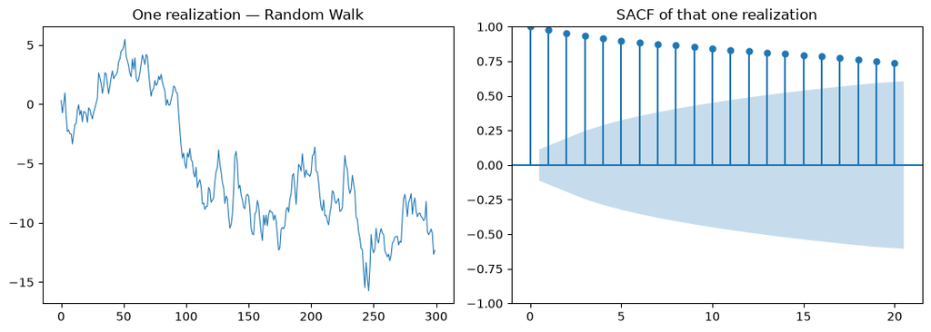

# Part 4: The Sample ACVF and ACF

## From Theory to Estimation

We never observe the population ACVF $\gamma_X(h)$ or ACF $\rho_X(h)$ — those belong to the model.

Given one observed path $x_1, \ldots, x_n$ of a stationary model, we estimate them.

**Sample autocovariance function (SACVF):**
$$\hat{\gamma}(h) = \frac{1}{n} \sum_{t=1}^{n-|h|} (x_{t+|h|} - \bar{x})(x_t - \bar{x}), \quad -n < h < n$$

**Sample autocorrelation function (SACF):**
$$\hat{\rho}(h) = \frac{\hat{\gamma}(h)}{\hat{\gamma}(0)}$$

## How Many Pairs Go Into $\hat{\gamma}(h)$?

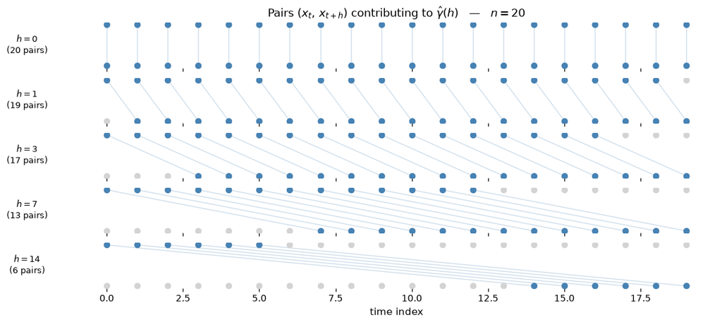

## Why Divide by $n$, Not $n - |h|$?

Dividing by $n$ (rather than the number of available pairs $n - |h|$) guarantees that the matrix $[\hat{\gamma}(i-j)]_{i,j=1}^m$ is **positive semi-definite** for any $m$.

Positive semi-definiteness is a necessary property of any valid covariance matrix. Without it, we could derive nonsensical model fits.

The cost: a small downward bias for large $|h|$.

## Confidence Bands Under IID

A special case of **Bartlett’s Formula** say that if $\{X_t\}$ is truly IID, for $h \geq 1$:

$$\hat{\rho}(h) \overset{\text{approx}}{\sim} N\!\left(0, \frac{1}{n}\right)$$

A 95% band is $\pm 1.96/\sqrt{n}$.

**Interpretation:** about 5% of lags will exceed the band by chance even for true IID noise. One or two exceedances in a 20-lag ACF plot are not alarming.

`statsmodels.graphics.tsaplots.plot_acf` has a `bartlett_confint=` parameter that can use alternative versions of Bartlett’s. For example, generalizing the iid assumption can produce larger standard errors and expanding bands at higher lags. We saw cone-shaped confidence intervals when mistakenly calculating SACF for the random walk.

# Part 5: CS 2 — FX Data Exploration

## Is AUD/JPY a Random Walk?

```python
import numpy as np
import pandas as pd
import matplotlib.pyplot as plt
from statsmodels.graphics.tsaplots import plot_acf

fx = pd.read_csv("../data/fx_rates.csv", index_col=0, parse_dates=True)
audjpy = fx["AUDJPY"].dropna()
log_price = np.log(audjpy)
log_ret = log_price.diff().dropna() * 100

fig, axes = plt.subplots(2, 2, figsize=(12, 6))
audjpy.plot(ax=axes[0, 0], title="AUD/JPY Spot Rate")
log_ret.plot(ax=axes[0, 1], title="AUD/JPY Log Returns (%)")
plot_acf(log_price.dropna(), lags=30, ax=axes[1, 0], title="SACF: Log Price")
plot_acf(log_ret, lags=30, ax=axes[1, 1], title="SACF: Log Returns")
plt.tight_layout()
plt.show()
```

## Is AUD/JPY a Random Walk?

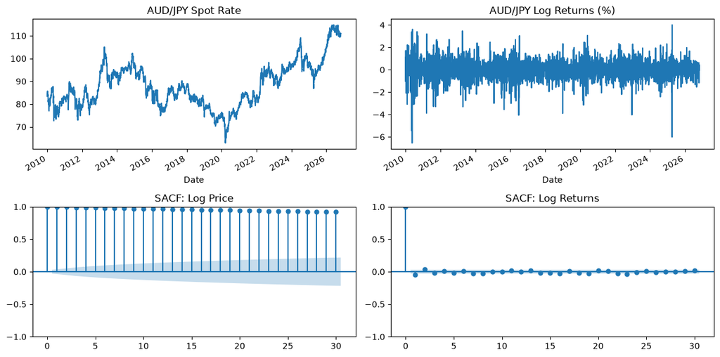

## Interpreting the Output

**Log price** of AUD/JPY:

- SACF decays very slowly — matches the random walk pattern from the simulations above
- Clearly non-stationary; $\bar{S}$ would be meaningless as an estimator. Not going to estimate a “long run exchange rate.”

**Log returns** (first differences):

- SACF values mostly within confidence bands
- Consistent with white noise — consistent with the Efficient Market Hypothesis
- $\bar{X}$ now has a well-defined target: the average daily carry return

However…

## Interpreting the Output

Theory versus practice: might be foolish to assume the true model doesn’t change over time.

It would be prudent to see how estimates change on a rolling window.

Second: the width of the returns seems to be varying. This is called **volatility clustering.** We’ll talk more about this in module 6!

## Mean Return of Naive Buy-and-Hold Carry Trade

Assuming the iid model, are either the mean spot return or the mean carry P&L **significantly** different from zero?

```python
import numpy as np
import pandas as pd

fx    = pd.read_csv("../data/fx_rates.csv", index_col=0, parse_dates=True)
rates = pd.read_csv("../data/rates.csv",    index_col=0, parse_dates=True)

spot_ret    = np.log(fx["AUDJPY"]).diff().dropna() * 100
aud_rate    = rates["AUD_rate"].reindex(spot_ret.index, method="ffill")
jpy_rate    = rates["JPY_rate"].reindex(spot_ret.index, method="ffill")
daily_carry = (aud_rate - jpy_rate) / 365
carry_pnl   = (spot_ret + daily_carry).dropna()
spot_ret    = spot_ret.reindex(carry_pnl.index)

for label, series in [("Spot log return", spot_ret), ("Carry P&L", carry_pnl)]:
    n    = len(series)
    xbar = series.mean()
    se   = series.std() / np.sqrt(n)
    print(f"{label}")
    print(f"  mean: {xbar:.4f}%   se: {se:.4f}%   "
          f"95% CI: ({xbar - 1.96*se:.4f}%, {xbar + 1.96*se:.4f}%)")
    print()
```

```
Spot log return
  mean: 0.0065%   se: 0.0118%   95% CI: (-0.0165%, 0.0296%)

Carry P&L
  mean: 0.0133%   se: 0.0118%   95% CI: (-0.0097%, 0.0364%)
```

## References

- Brockwell, P. J. & Davis, R. A. (2016). *Introduction to Time Series and Forecasting* (3rd ed.). Springer.